# Potatoes Cold Climate Adaptation

Sina Mokhtar

2023-03-26

```r
library(dplyr)
```

```r
library(ggplot2)
library(car)
library(erikmisc)
library(MASS)
```

## Read Potato Data

```r
potato.file=read.table("rawData/potato.txt",header=TRUE)
```

## Clean Data

```r
potato = potato.file %>%
    dplyr::mutate(regime = factor(regime,label=c("R","C")),
                  variety = factor(variety,label=c("s1","s2")),
                  temp = factor(temp, label=c("-4","-8")),
                  id = 1:n())
attach(potato)
head(potato)
```

|  | variety | regime | temp | photo | leak | id |
| --- | --- | --- | --- | --- | --- | --- |
| 1 | s1 | R | -4 | 4.6386 | 2.25 | 1 |
| 2 | s1 | R | -4 | 5.7914 | 4.34 | 2 |
| 3 | s1 | R | -4 | 29.3515 | 4.25 | 3 |
| 4 | s1 | R | -4 | 18.4173 | 6.14 | 4 |
| 5 | s1 | R | -4 | 2.2556 | 2.38 | 5 |
| 6 | s1 | R | -8 | 8.2358 | 16.30 | 6 |

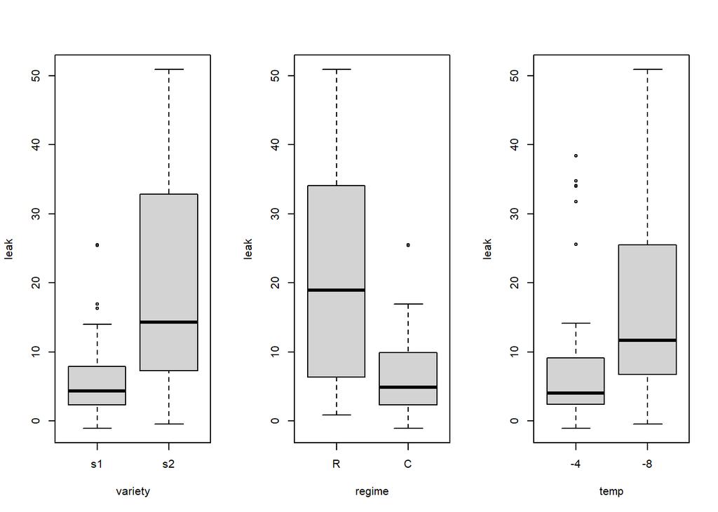

```r
par(mfrow=c(1,3))
boxplot(leak ~ variety,
data = potato)
boxplot(leak ~ regime,
data = potato)
boxplot(leak ~ temp,
data = potato)
```

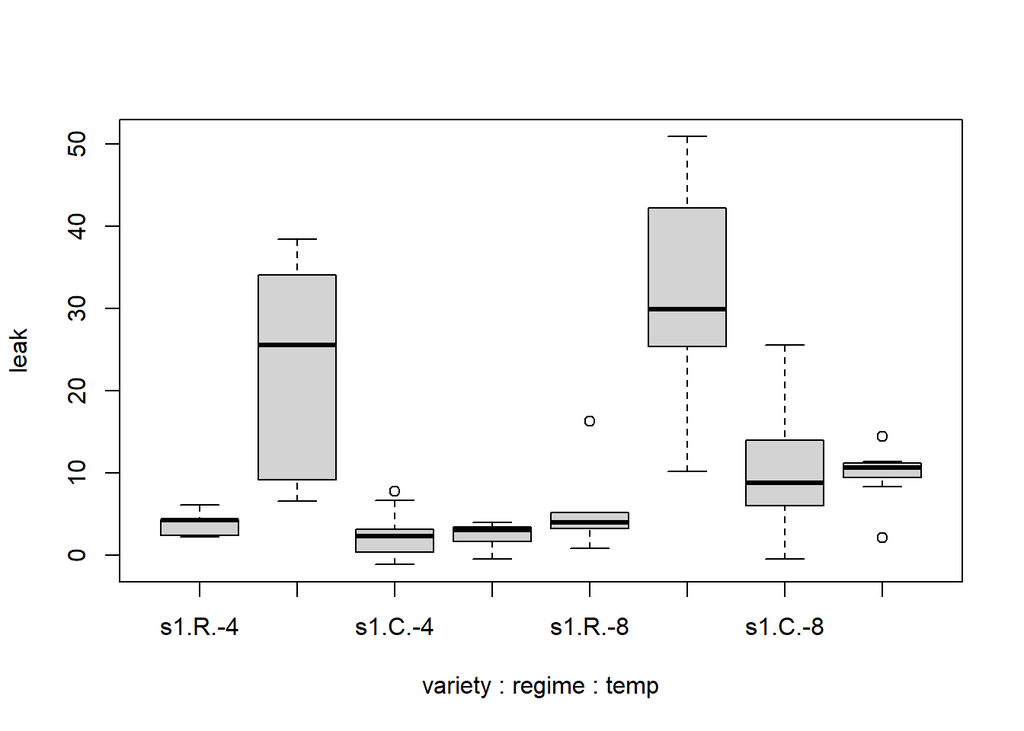

```r
boxplot(leak ~ variety:regime:temp,
data = potato)
```

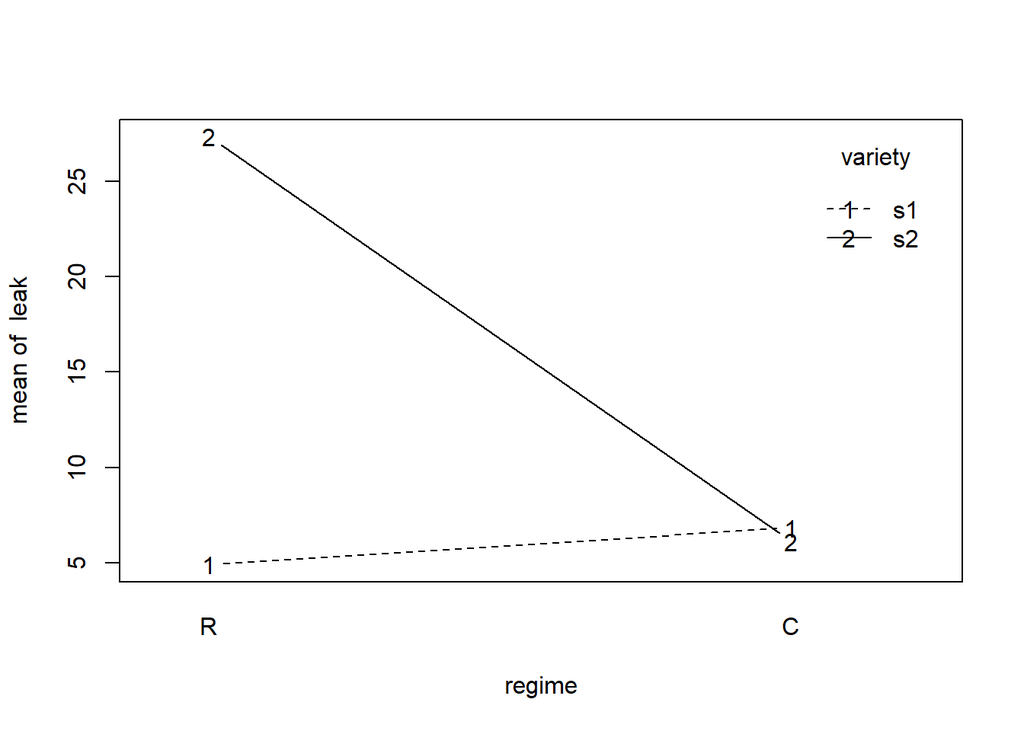

```r
interaction.plot(regime, variety, leak, type="b")
```

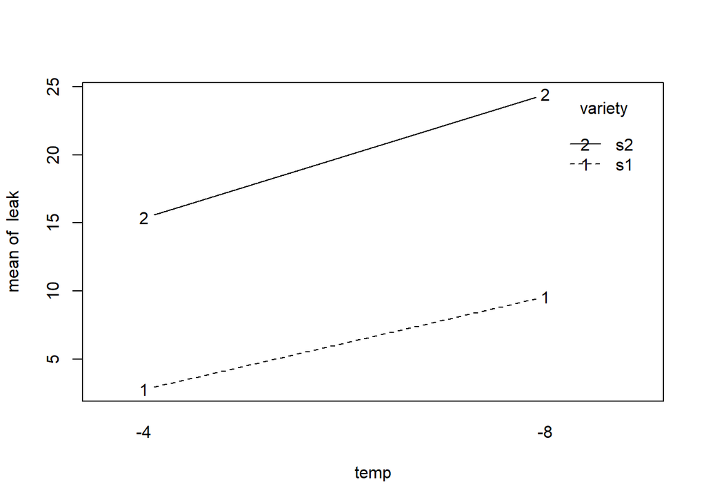

```r
interaction.plot(temp, variety, leak, type="b")
```

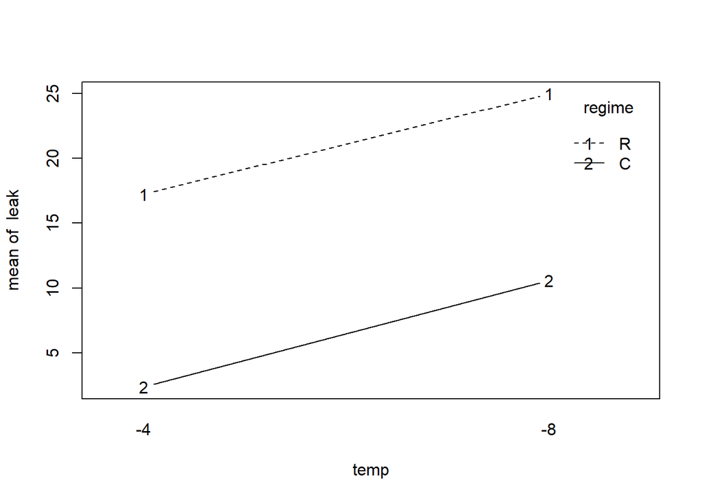

```r
interaction.plot(temp, regime, leak, type="b")
```

## Fit the model

```r
potato = potato %>%
    dplyr::mutate(leak_positive = leak + 2)
attach(potato)
```

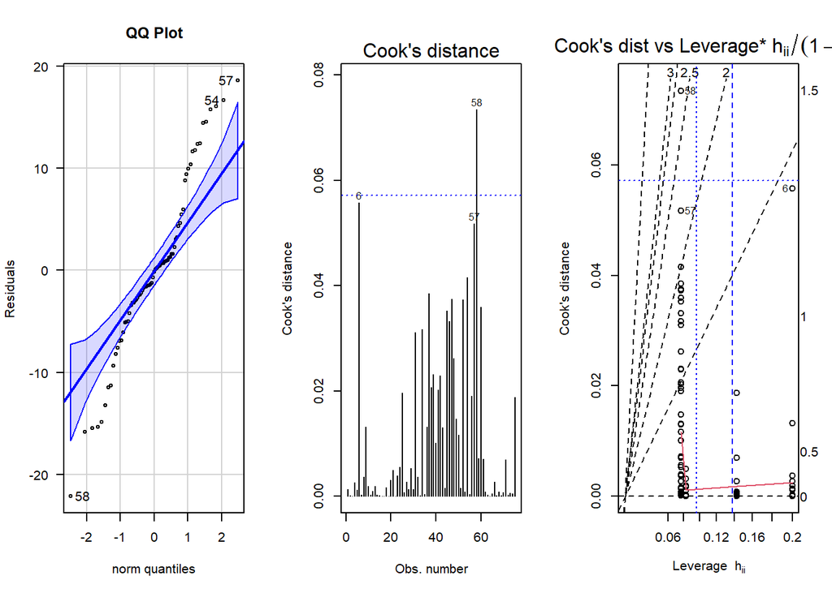

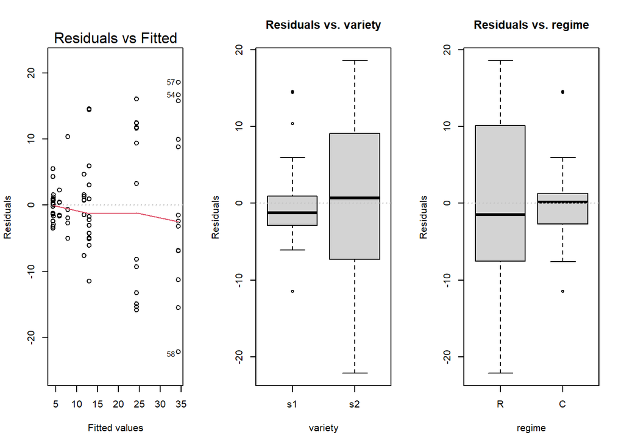

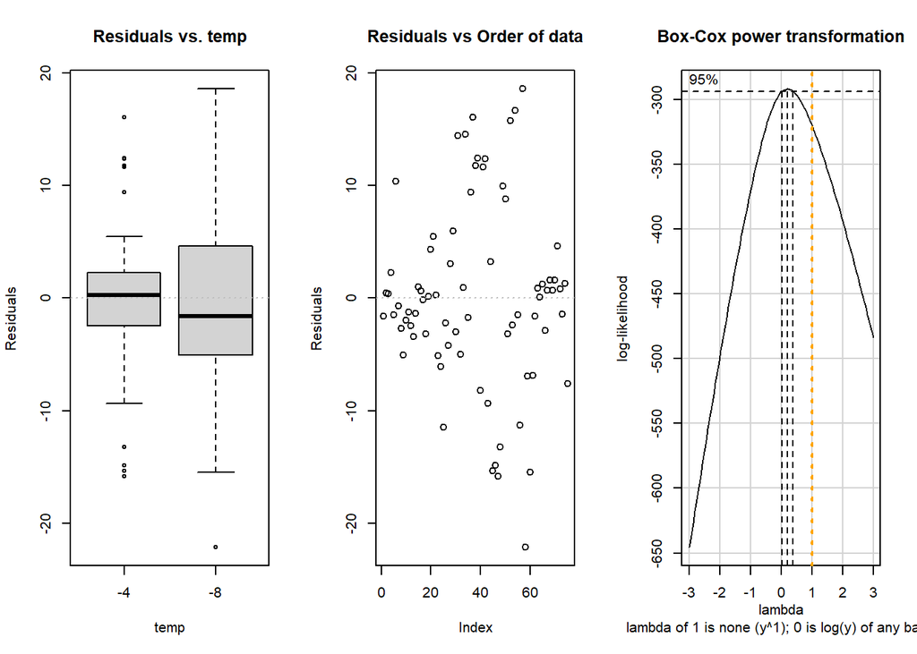

```
## Non-constant Variance Score Test
## Variance formula: ~ fitted.values
## Chisquare = 31.92935, Df = 1, p = 1.5988e-08
```

```
## there are higher-order terms (interactions) in this model
## consider setting type = 'predictor'; see ?vif
```

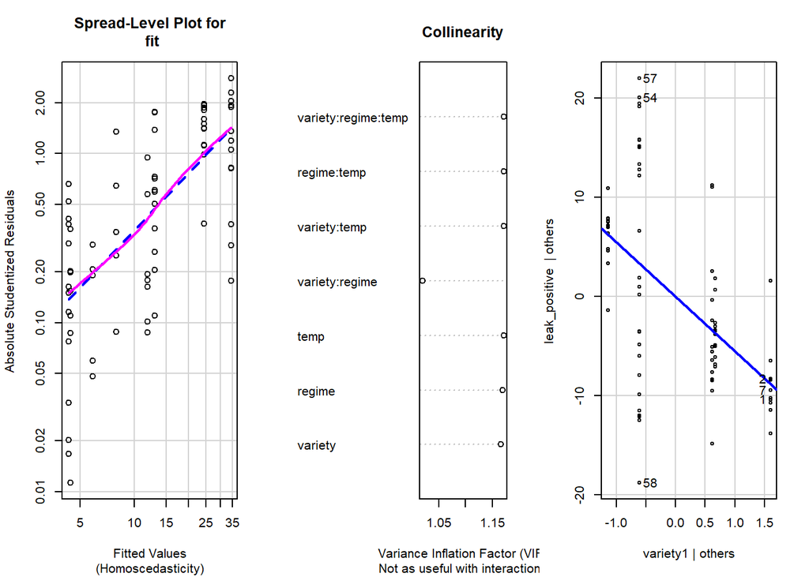

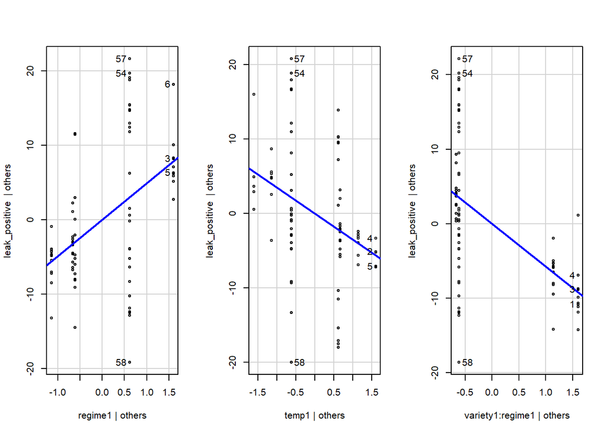

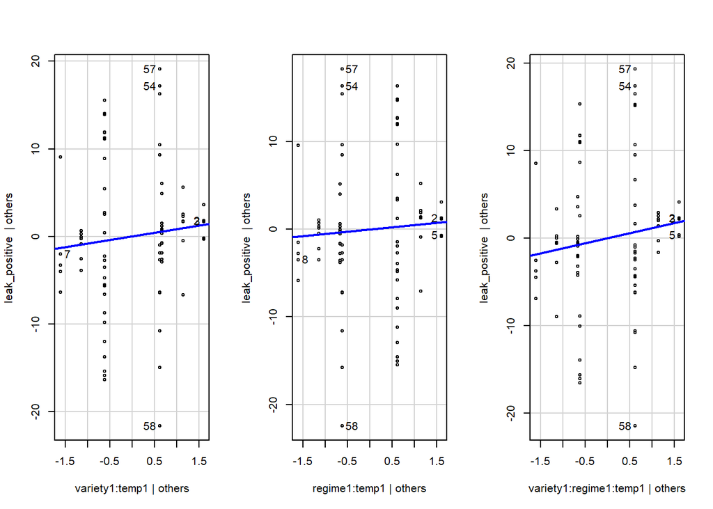

```r
myfit<-lm(leak_positive~variety*regime*temp,
contrasts = c(variety=contr.sum, regime=contr.sum,temp=contr.sum))
e_plot_lm_diagostics(myfit)
```

```r
boxcox = boxcox(myfit, lambda = seq(-3, 3, length = 10))
```

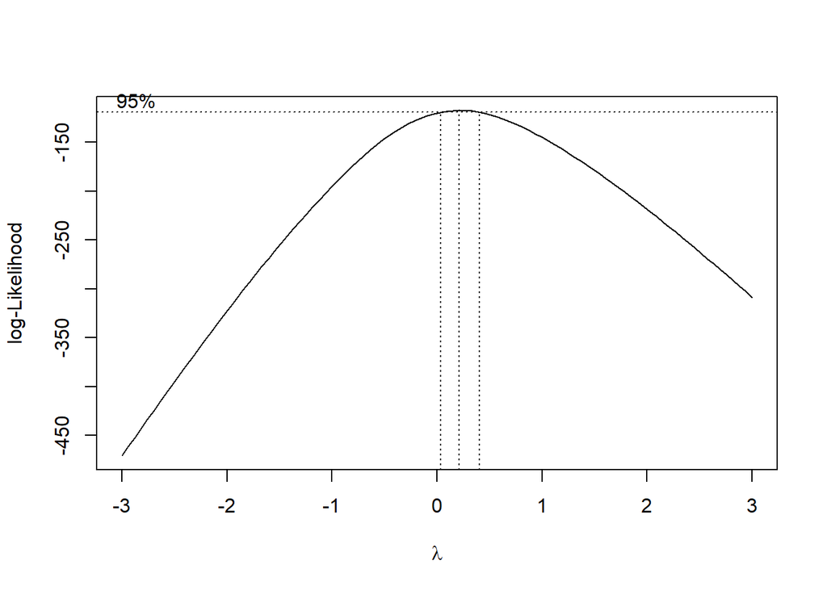

```r
# find optimize lambda

optlambda = boxcox$x[which.max(boxcox$y)]
optlambda
```

```
## [1] 0.2121212
```

```r
potato = potato %>%
    dplyr::mutate(leak_trans = leak_positive^optlambda)
attach(potato)
```

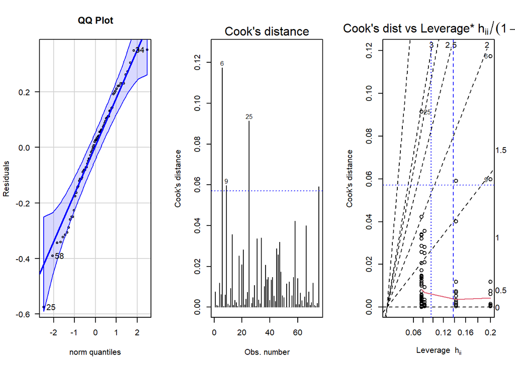

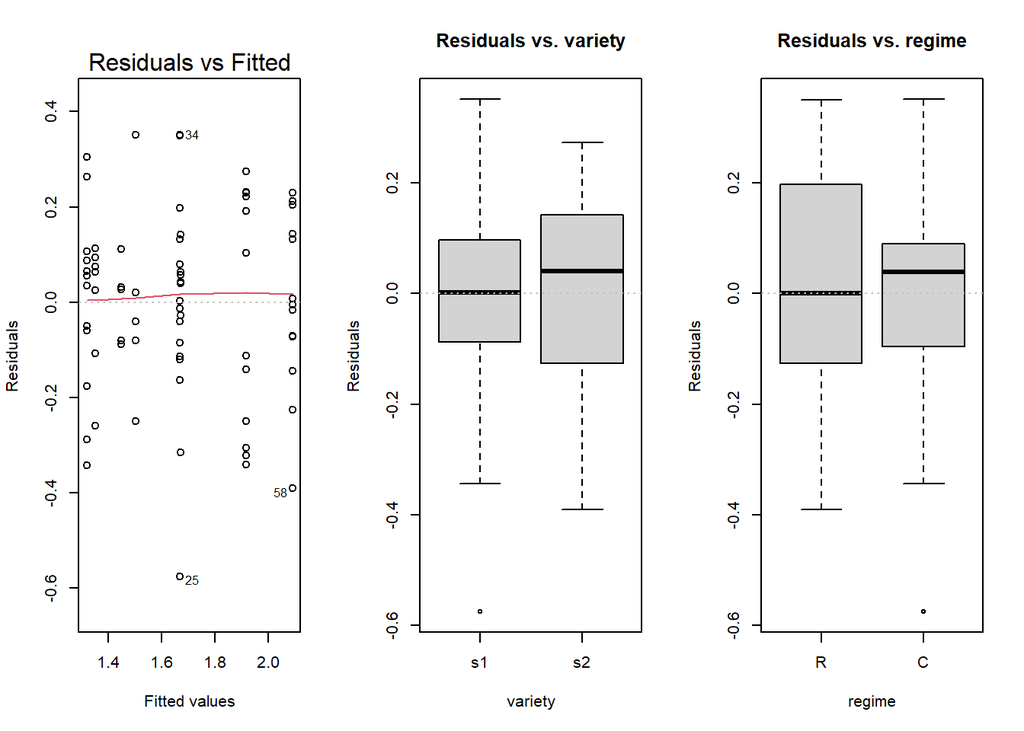

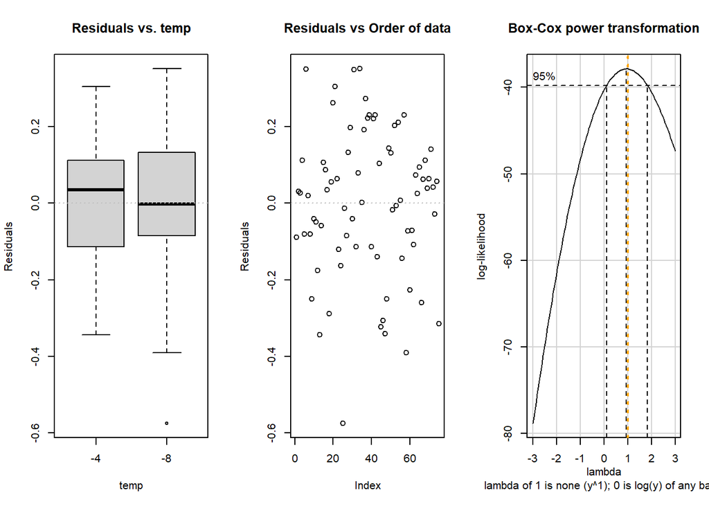

```
## Non-constant Variance Score Test
## Variance formula: ~ fitted.values
## Chisquare = 0.9601756, Df = 1, p = 0.32714
```

```
## there are higher-order terms (interactions) in this model
## consider setting type = 'predictor'; see ?vif
```

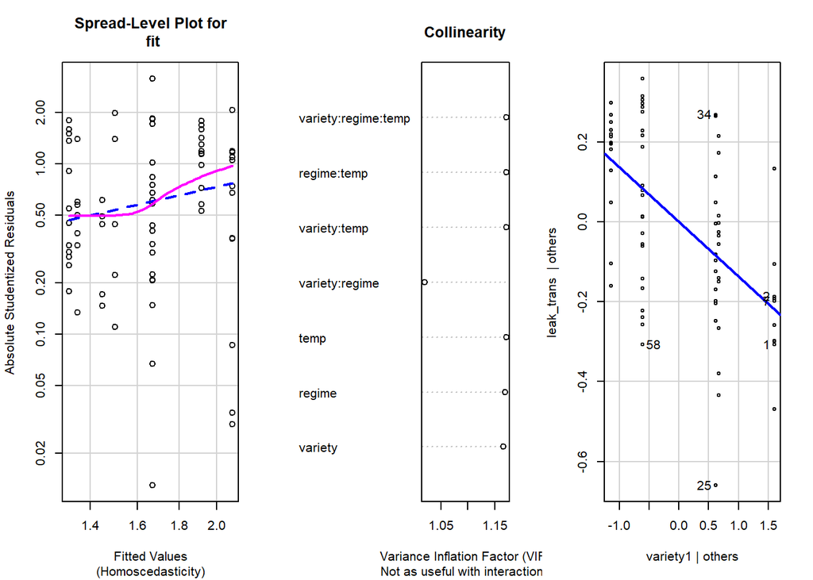

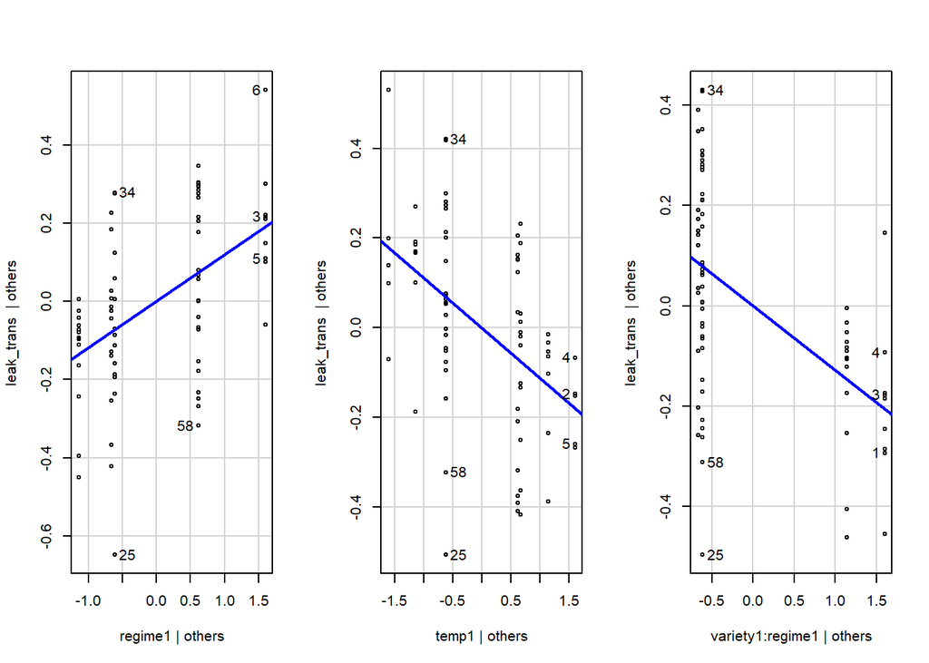

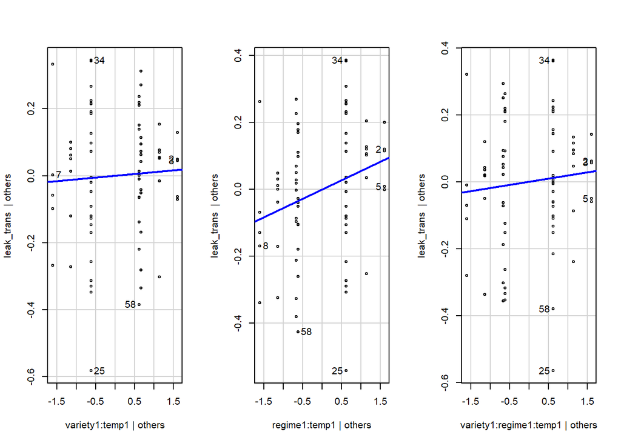

```r
myfit_trans<-lm(leak_trans~variety*regime*temp,
contrasts = c(variety=contr.sum, regime=contr.sum,temp=contr.sum))
e_plot_lm_diagostics(myfit_trans)
```

```r
#outlier test
outlierTest(myfit_trans)
```

```
## No Studentized residuals with Bonferroni p < 0.05
## Largest |rstudent|:
##     rstudent unadjusted p-value Bonferroni p
## 25 -3.152623          0.0024345      0.18259
```

observation 25 has a standardized residual (rstudent) of -3.152623, and the Bonferroni p-value for observation 25 is 0.18259, which is greater than the conventional threshold of 0.05. This suggests that observation 25 is not statistically significant after correcting for multiple testing. Overall, observation 25 may be a potential outlier or influential observation but we keep it in model.

```r
# violation of constant variance observed, not serious
leveneTest(leak_trans~variety*temp*regime, data=potato)
```

|  | Df | F value | Pr(>F) |
| --- | --- | --- | --- |
| group | 7 | 1.281869 | 0.2727386 |
|  | 67 | NA | NA |

```r
# shapiro test residuals normality
shapiro.test(myfit_trans$residuals)
```

```
##
##  Shapiro-Wilk normality test
##
## data:  myfit_trans$residuals
## W = 0.97926, p-value = 0.2559
```

Since the p-value is greater than the significance level (0.05), we fail to reject the null hypothesis that the residuals is normally distributed. Therefore, we can conclude that the residuals is normally distributed.

```r
Anova(myfit_trans, type=3)
```

|  | Sum Sq | Df | F value | Pr(>F) |
| --- | --- | --- | --- | --- |
| (Intercept) | 1.681818e+02 | 1 | 4104.9696312 | 7.634365e-62 |
| variety | 1.191608e+00 | 1 | 29.0846807 | 9.724994e-07 |
| regime | 9.017248e-01 | 1 | 22.0092426 | 1.382549e-05 |
| temp | 8.003673e-01 | 1 | 19.5353144 | 3.702920e-05 |
| variety:regime | 1.049885e+00 | 1 | 25.6255205 | 3.460793e-06 |
| variety:temp | 7.774686e-03 | 1 | 0.1897640 | 6.645133e-01 |
| regime:temp | 1.960192e-01 | 1 | 4.7844249 | 3.221236e-02 |
| variety:regime:temp | 2.254935e-02 | 1 | 0.5503831 | 4.607540e-01 |
| Residuals | 2.745009e+00 | 67 | NA | NA |

```r
fit_reduced = update(myfit_trans, . ~ . -variety:regime:temp)
Anova(fit_reduced, type=3)
```

|  | Sum Sq | Df | F value | Pr(>F) |
| --- | --- | --- | --- | --- |
| (Intercept) | 1.682136e+02 | 1 | 4133.0758793 | 1.254803e-62 |
| variety | 1.189555e+00 | 1 | 29.2278479 | 8.955361e-07 |
| regime | 8.999343e-01 | 1 | 22.1117420 | 1.301744e-05 |
| temp | 1.048143e+00 | 1 | 25.7533007 | 3.216071e-06 |
| variety:regime | 1.051902e+00 | 1 | 25.8456466 | 3.106525e-06 |
| variety:temp | 5.241004e-03 | 1 | 0.1287735 | 7.208189e-01 |
| regime:temp | 1.829625e-01 | 1 | 4.4954614 | 3.763625e-02 |
| Residuals | 2.767558e+00 | 68 | NA | NA |

The interaction term variety:temp in the ANOVA table has a p-value of 0.72082, which is greater than the conventional significance level of 0.05. Therefore, we do not have evidence to reject the null hypothesis that the interaction term is not significant. So, variety:temp is not significant

```r
fit_reduced = update(fit_reduced, . ~ . -variety:temp)
Anova(fit_reduced, type=3)
```

|  | Sum Sq | Df | F value | Pr(>F) |
| --- | --- | --- | --- | --- |
| (Intercept) | 168.2088127 | 1 | 4185.809202 | 1.691695e-63 |
| variety | 1.1907448 | 1 | 29.631209 | 7.509585e-07 |
| regime | 0.9009619 | 1 | 22.420079 | 1.130676e-05 |
| temp | 1.0692892 | 1 | 26.608835 | 2.275807e-06 |
| variety:regime | 1.0508948 | 1 | 26.151097 | 2.701029e-06 |
| regime:temp | 0.1856692 | 1 | 4.620304 | 3.510467e-02 |
| Residuals | 2.7727991 | 69 | NA | NA |

```r
finalfit = fit_reduced
```

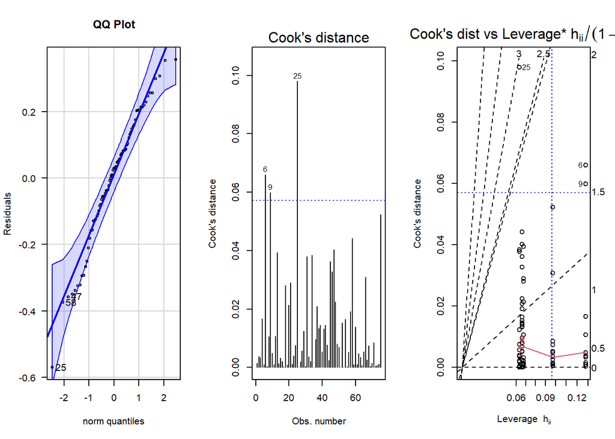

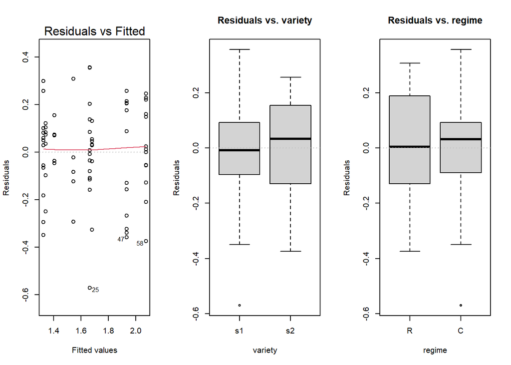

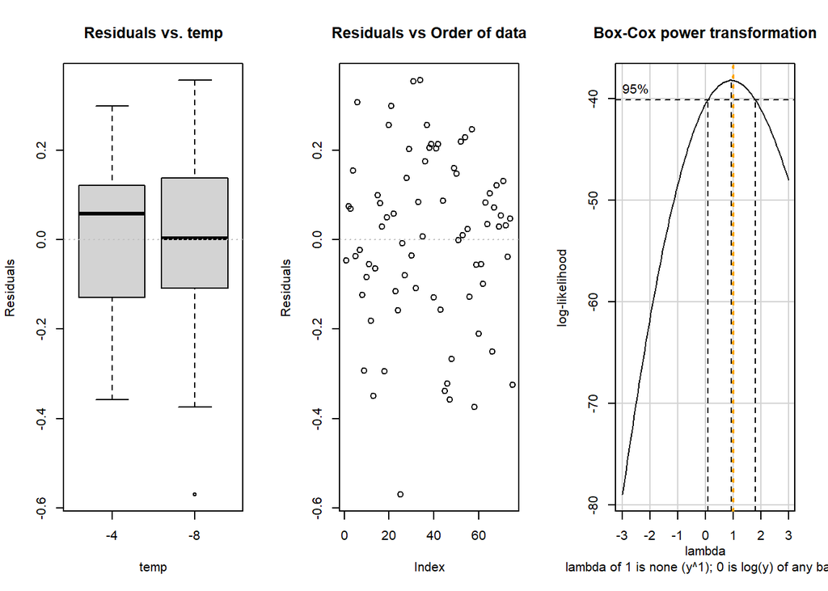

```
## Non-constant Variance Score Test
## Variance formula: ~ fitted.values
## Chisquare = 1.103575, Df = 1, p = 0.29348
```

```
## there are higher-order terms (interactions) in this model
## consider setting type = 'predictor'; see ?vif
```

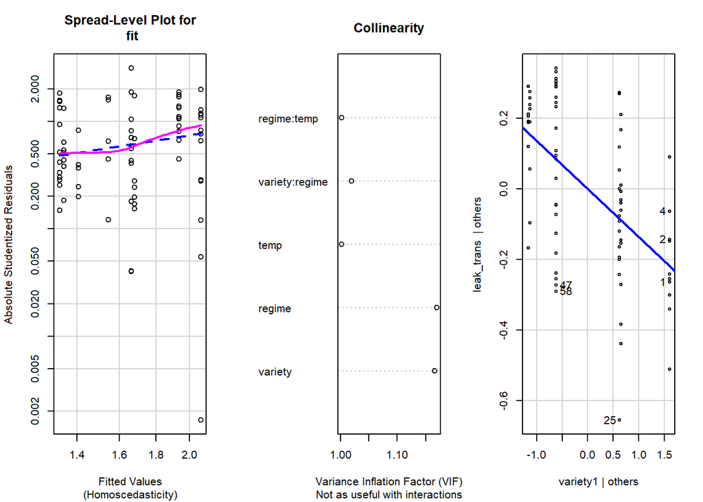

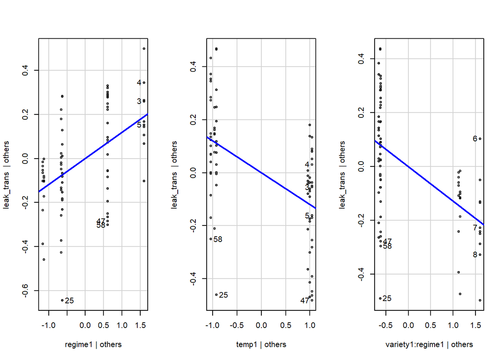

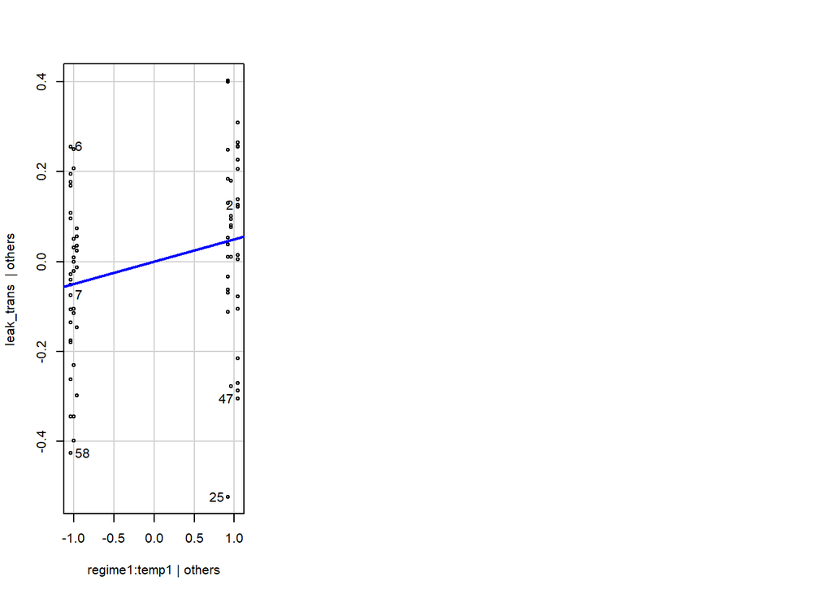

```r
e_plot_lm_diagostics(finalfit)
```